# **Raw read processing for paired amplicons: Danae B Dataset**

Raw sequence processing and OTU table generation using usearch v11

Kelli Feeser

2025

# **Raw fastq processing for Dataset_Danae_B**

*Note that sample 128 (16S) and 215 (ITS) are missing due lack of any usable sequence data.*

# **1 Review quality of raw .fastqs**

**FastQC version**

```
## FastQC v0.12.1
```

## Per base quality scores

*Phred scores along length of amplicon*

### 16S fwd

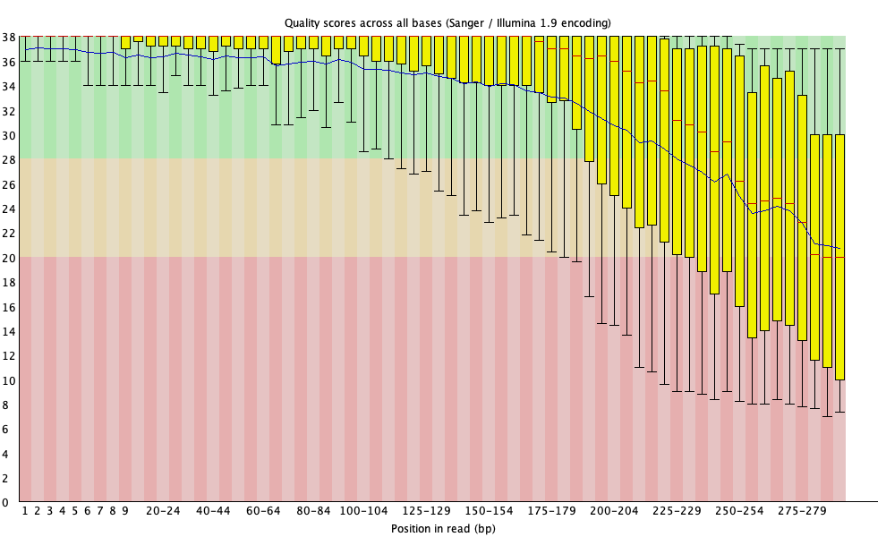

Per base quality score

### 16S rev

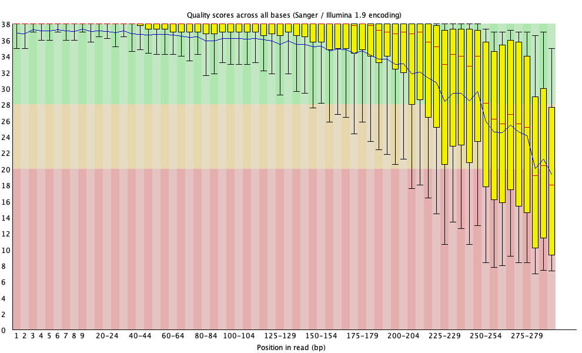

Per base quality score

### ITS fwd

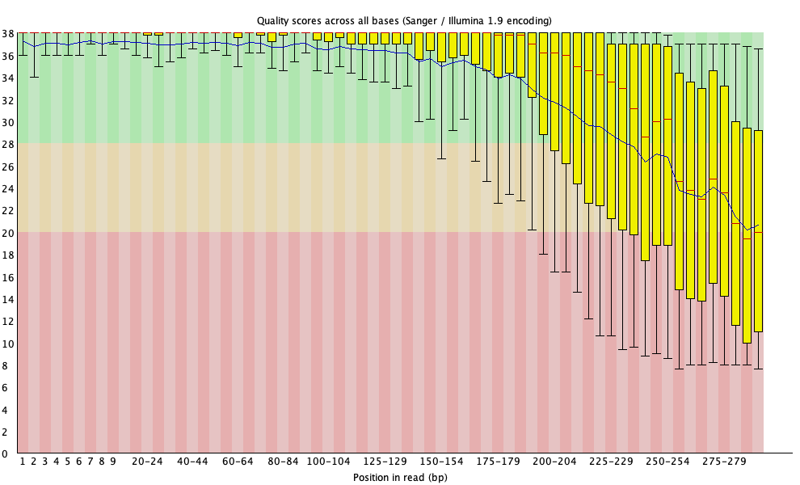

Per base quality score

### ITS rev

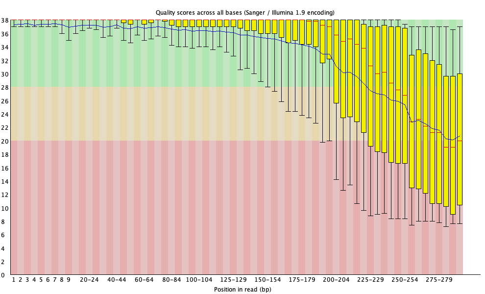

Per base quality score

## Quality score distribution

*Quality score distribution among all sequences*

### 16S fwd

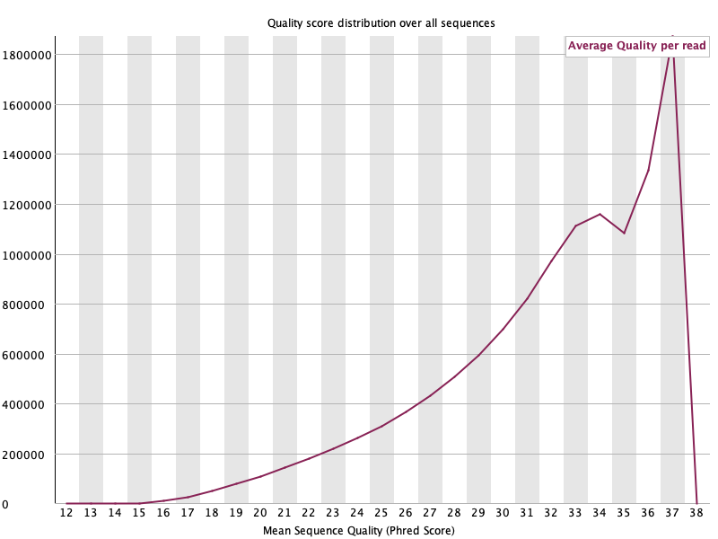

### 16S rev

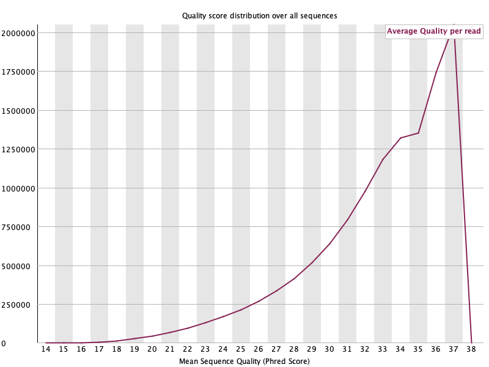

### ITS fwd

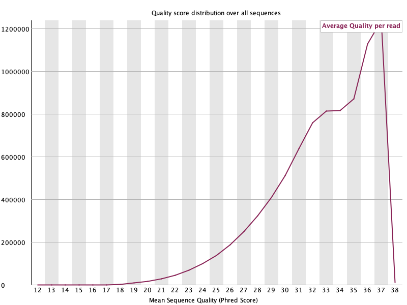

### ITS rev

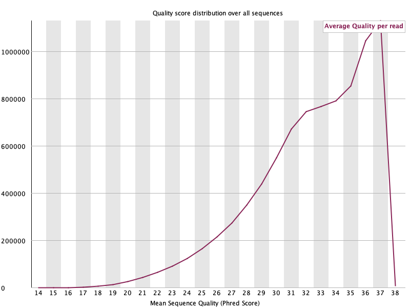

## Per base sequence content

*Nucleotide content along length of amplicon, note adapter/primer content in first ~20 bp*

### 16S fwd

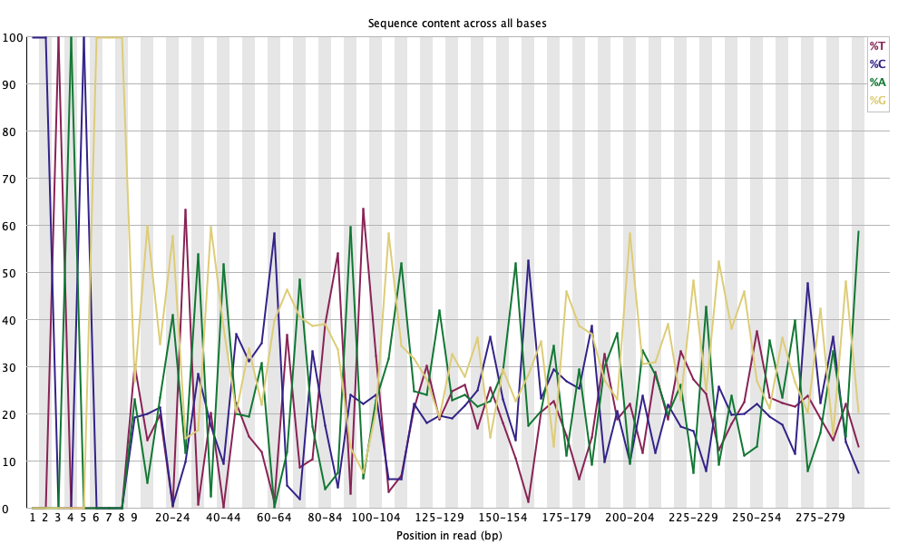

### 16S rev

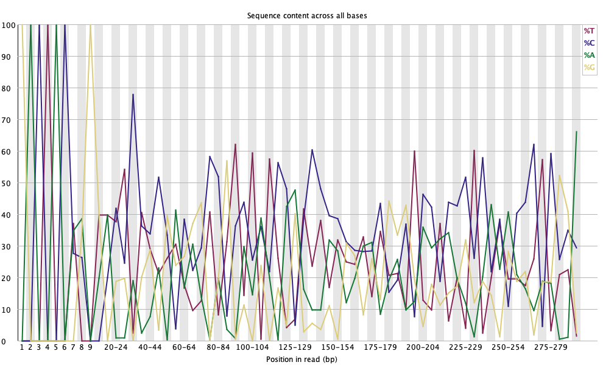

### ITS fwd

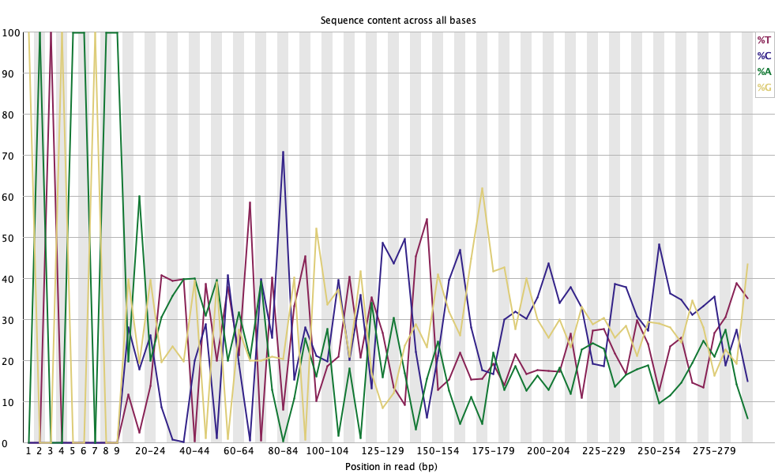

### ITS rev

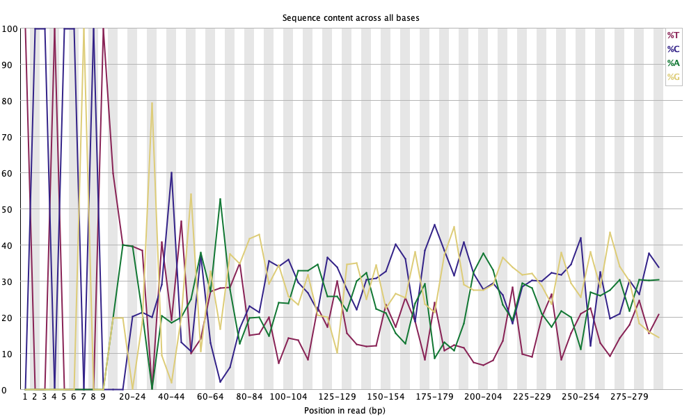

# **2 Methods for Sequence Processing using usearch11**

**USEARCH version v11.0.667_i86osx64**

usearch v11.0.667_i86osx64, 68.7Gb RAM, 16 cores  
(C) Copyright 2013-18 Robert C. Edgar, all rights reserved.  
https://drive5.com/usearch\

*Note that all steps were performed separately for the 16S and ITS datasets*

## Step 1: Merge paired-end reads

[output not shown]

Same flags for 16S and ITS

```bash
for i in *_R1.fastq
  do
 usearch -fastq_mergepairs $i -fastq_pctid 90 -fastq_maxdiffs 20 -fastq_trunctail 30 -fastq_minmergelen 150 -relabel ${i:0:9}. -fastqout 2_ReadProcessing/16S_merged/${i:0:9}_merged.fastq
  done
```

Summary of merging individual paired files:

### 16S Merging Results

~10.8 million reads merged with a success rate of 87.4%

### ITS Merging Results

~7.8 million reads merged with a success rate of 93.7%

## Step 2: Trim Primers

16S primers  
341F - CCTACGGGNGGCWGCAG [17 bp]  
805R - GACTACHVGGGTATCTAATCC [21 bp]

ITS primers  
ITS3_KYO2 - GATGAAGAACGYAGYRAA [18 bp]  
ITS4 - TCCTCCGCTTATTGATATGC [20 bp]

[output not shown]

```bash
for i in *_merged.fastq
  do
 usearch -fastx_truncate $i -stripleft 17 -stripright 13 -fastqout 2_ReadProcessing/16S_filtered/${i:0:9}_filtered.fastq
  done
```

### 16S Trimming

Total reads: 10,824,154  
Total length: 4,502,491,908 bp  
Avg. seq: 415.97 bp  
Median seq: 426.00 bp  
N 50: 426 bp  
Min seq: 112 bp  
Max seq: 525 bp

## Step 3: QC by max EE and minimum length filtering

**Phred scores**  
Next-generation reads specify a Phred score for each base, also known as a Quality or Q score. Q=20 corresponds to an error probability of 1%.

**Expected number of errors**  
Assume that the Phred scores are good, in other words assume that the machine makes good estimates of the error probabilities. Now we can measure the overall quality of a read by calculating the **expected number of errors** in the read. The Q scores can’t tell us exactly how many errors there are in a given read. However, the Q scores can tell us what the average number of errors would be in that large collection, and this is the definition of the expected number of errors. Because we’re taking an average, the value is real rather than integer, and can be less than one. To calculate the expected number of errors: it is the sum of the error probabilities.

**Choosing the maximum expected error threshold**  
A natural choice is E_max = 1, because the most probable number of errors of a filtered read is zero.

**When to QC**

Our paired read merger (assembler) reported re-calculated Phred scores in the overlapping region to reflect that we have two independent observations of the same bases. If the forward and reverse read agree on a base, then our confidence that the base is correct should increase. Quality filtering by maximum expected errors should be performed as a post-processing step after reads have been merged in order to take advantage of the re-calculated Phred scores, which should be better predictions of the true error rates.

| Flags | 16S value | ITS value | Explanation |
| --- | --- | --- | --- |
| -fastq_maxee | 1.0 | 1.0 | Discard reads with > E total [expected errors](https://www.drive5.com/usearch/manual/exp_errs.html) for all bases in the read after any truncation options have been applied. |
| -fastq_minlen | 240 | 240 | Discard sequences with < L letters. |

```bash
for i in *_filtered.fastq
  do
 usearch -fastq_filter $i -fastq_maxee 1.0 -fastq_minlen 240 -fastaout 2_ReadProcessing/16S_qcd/${i:0:9}_qcd.fasta
  done
```

### 16S QC

*sum of read counts*

[output not shown]

Total reads: 8,607,409  
Total length: 3,585,168,763 bp  
Avg. seq: 416.52 bp  
Median seq: 426.00 bp  
N 50: 426 bp  
Min seq: 240 bp  
Max seq: 525 bp

### ITS QC

*sum of read counts*

| Raw Count (Total) | Count Discarded (EE > 1.00) | Count Passing QC | Pass Rate |
| --- | --- | --- | --- |
| 7,765,505 (7.8M) | 656,123 | 7,020,824 (7.0M) | 90.4% |

Total reads: 7,020,824  
Total length: 2,420,275,239 bp  
Avg. seq: 344.73 bp  
Median seq: 311.00 bp  
N 50: 321 bp  
Min seq: 241 bp  
Max seq: 513 bp

## Step 4: Find unique sequences in each dataset and add size annotations to .fasta headers

### 16S

*abundance/occurrence of sequences across datasets*

```bash
./../../usearch -fastx_uniques 2_ReadProcessing/16S_qcd_from_individs.fasta -sizeout -relabel uniq -fastaout 2_ReadProcessing/16S_individ_uniques.fasta
```

Reading 2_ReadProcessing/16S_qcd_from_individs.fasta

- 8,607,409 sequences
- 945,254 uniques
- 764,612 singletons (80.9%)
- Sequence abundance in dataset:
  - Min: 1
  - Median: 1
  - Mean: 9.11
  - Max: 825,329

### ITS

*abundance/occurrence of sequences across datasets*

```bash
./../../usearch -fastx_uniques 2_ReadProcessing/ITS_qcd_from_individs.fasta -sizeout -relabel uniq -fastaout 2_ReadProcessing/ITS_individ_uniques.fasta
```

Reading 2_ReadProcessing/ITS_qcd_from_individs.fasta

- 7,020,824 sequences
- 382,416 uniques
- 289,475 singletons (75.7%)
- Sequence abundance in dataset:
  - Min: 1
  - Median: 1
  - Mean: 18.36
  - Max: 1,504,845

## Step 5: Remove singleton sequences

*16S:*

```bash
./../../usearch -sortbysize 2_ReadProcessing/16S_individ_uniques.fasta -minsize 2 -fastaout 2_ReadProcessing/16S_individ_derep_min2.fasta
```

Reading 2_ReadProcessing/16S_individ_uniques.fasta  
Getting sizes  
Sorting 180,642 sequences

*ITS:*

```bash
./../../usearch -sortbysize 2_ReadProcessing/ITS_individ_uniques.fasta -minsize 2 -fastaout 2_ReadProcessing/ITS_individ_derep_min2.fasta
```

Reading 2_ReadProcessing/ITS_individ_uniques.fasta  
Getting sizes  
Sorting 92,941 sequences

## Step 6: Cluster OTUs in each dataset

### 16S

```bash
./../../usearch -cluster_otus 2_ReadProcessing/16S_individ_derep_min2.fasta -relabel OTU -otus 3_OTUs/16S_OTUs/16S_individ_otus.fa
```

3,086 OTUs 6,083 chimeras

### ITS

```bash
./../../usearch -cluster_otus 2_ReadProcessing/ITS_individ_derep_min2.fasta -relabel OTU -otus 3_OTUs/ITS_OTUs/ITS_individ_otus.fa
```

829 OTUs 78 chimeras

## Step 7: Map trimmed reads to the representative OTU sequences in each dataset

The reads we are mapping are the output of step 2: the paired-end reads have been merged and the primers truncated, but the reads have not been quality filtered yet. Note that sequences across all samples have been concatenated into 1 file and the fasta headers reflect the sample id. The representative OTU sequence is the most abundance sequence in an OTU cluster.

```bash
usearch -otutab 2_ReadProcessing/16S_filtered_all.fastq -otus 3_OTUs/16S_OTUs/16S_individ_otus.fa -otutabout 3_OTUs/16S_OTUs/16S_otutab_kf.txt -mapout 3_OTUs/16S_OTUs/16S_map_kf.txt
```

### 16S

10,420,615 / 10,824,154 mapped to OTUs (96.3%)

### ITS

7,658,548 / 7,765,505 mapped to OTUs (98.6%)

## Step 8: Assign taxonomy to 16S rep set sequences

Database: SILVA v138 SSU Ref NR99  
https://www.arb-silva.de/documentation/release-138/

```bash
../../../tools/usearch11.0.667_i86osx64 -sintax 3_OTUs/16S_OTUs/16S_individ_otus.fa -db /Users/L347123/Desktop/ReadProcessing/ref_dbs/SILVA_138_NR99_AutoTax/AutoTax_SILVA_138_Nr99_sintax.fa -tabbedout 4_Taxonomy_SINTAX/16S_sintax_SILVA_138_NR99_AutoTax.txt -strand both -sintax_cutoff 0.8
```

### Database: RDP 16S training set v18

Database: RDP 16S training set v18  
source: https://sourceforge.net/projects/rdp-classifier/files/RDP_Classifier_TrainingData/RDPClassifier_16S_trainsetNo18_rawtrainingdata/trainset18_062020.fa\

```bash
./../../usearch -sintax 3_OTUs/16S_OTUs/16S_individ_otus.fa -db ../ref_dbs/rdp_16s_v18.udb -tabbedout 4_Taxonomy_SINTAX/16S_sintax_rdp_16s_v18.txt -strand both -sintax_cutoff 0.8
```

## Step 9: Assign taxonomy to ITS rep set sequences

Database: UNITE All eukaryotes No 9

```
## ITS taxonomy
##
## ref db:
## Title        UNITE USEARCH/UTAX release for eukaryotes
## Location https://dx.doi.org/10.15156/BIO/2938084
## Published    2023
## Creators Abarenkov, Kessy; Zirk, Allan; Piirmann, Timo; Pöhönen, Raivo; Ivanov, Filipp; Nilsson, R. Henrik; Kõljalg, Urmas.
## Date Created 2023-07-18
## Date updated 2023-07-25
## Date downloaded  2023-08-11
## Abstract Reference file for USEARCH/UTAX. For optimized parameters and further information, please refer to the UTAX UNITE page.
##      This is the "dynamic" release of the UNITE species hypotheses system, with singleton species hypotheses included. Any parts of the 18S and 28S are left in these sequences.
##      This reference file can be used for ITS1-only or ITS2-only sequences if parameters trained on ITS1 or 2 only ('taxconfs' files) are used. ITS regions can be extracted using the ITSx tool.
## Citation Abarenkov, Kessy; Zirk, Allan; Piirmann, Timo; Pöhönen, Raivo; Ivanov, Filipp; Nilsson, R. Henrik; Kõljalg, Urmas (2023): UNITE USEARCH/UTAX release for eukaryotes. UNITE Community. 10.15156/BIO/2938084
## File name    utax_reference_dataset_all_25.07.2023.fasta
##
## Version no   9.0
## Release date 2023-07-18
## Taxon group  All eukaryotes
## No of seqs   326 727
##
## ######
## #making sintax format
## #$ usearch -makeudb_usearch unite_general_release_dynamic_s_all_18.07.2023.fasta -output unite_alleuk_18.07.2023.udb
## #####
```

### 0.0.1 read-in raw USEARCH OTU tables, taxonomy, and metadata —-

#### read-in raw 16S data

##### 16S otu table

##### 16S sintax taxonomy file (SILVA)

16S ref db: SILVA v138 SSU Ref NR99

##### 16S sintax taxonomy file (RDP)

16S ref db: RDP 16S v18

##### 16S metadata file

#### read-in raw ITS data

##### ITS sintax taxonomy file

ITS ref db: unite all euks 25.07.2023

# **3 Sequence Processing Results**

### Brief overview

**16S**

```
## phyloseq-class experiment-level object
## otu_table()   OTU Table:         [ 3085 taxa and 284 samples ]
## sample_data() Sample Data:       [ 284 samples by 28 sample variables ]
## tax_table()   Taxonomy Table:    [ 3085 taxa by 6 taxonomic ranks ]
```

(“taxa” are OTUs)

**ITS**

```
## phyloseq-class experiment-level object
## otu_table()   OTU Table:         [ 829 taxa and 284 samples ]
## sample_data() Sample Data:       [ 284 samples by 28 sample variables ]
## tax_table()   Taxonomy Table:    [ 829 taxa by 7 taxonomic ranks ]
```

### Summary Read Stats

| Seqs per sample | 16S amplicons | ITS amplicons |
| --- | --- | --- |
| min | 0 | 0 |
| max | 102,786 | 108,979 |
| mean | 36,692 | 26,967 |
| sd | 15,042 | 22,508 |
| total | 10,420,615 | 7,658,548 |

### Unique Domains detected

#### 16S - SILVA

Bacteria, Archaea, uncl_Domain

#### 16S - RDP

Bacteria, uncl_Domain, Archaea, Eukaryota

#### ITS

Fungi, Viridiplantae, uncl_Domain, unidentified, Metazoa, Alveolata, Heterolobosa, Stramenopila

### Reads per Domain

#### 16S - SILVA

| Domain | reads_assigned | percentage_all_reads |
| --- | --- | --- |
| Bacteria | 10,415,483 | 99.95% |
| Archaea | 4,222 | 0.04% |
| uncl_Domain | 910 | 0.01% |

*For now, only continuing with reads assigned at >= 80% confidence to domain = Bacteria or Archaea*

#### 16S - RDP

| Domain | reads_assigned | percentage_all_reads |
| --- | --- | --- |
| Bacteria | 10,398,535 | 99.79% |
| uncl_Domain | 4,098 | 0.04% |
| Archaea | 6,558 | 0.06% |
| Eukaryota | 11,424 | 0.11% |

*For now, only continuing with reads assigned at >= 80% confidence to domain = Bacteria or Archaea*

#### ITS

| Domain | reads_assigned | percentage_all_reads |
| --- | --- | --- |
| Fungi | 7,050,251 | 92.06% |
| Viridiplantae | 532,523 | 6.95% |
| uncl_Domain | 858 | 0.01% |
| unidentified | 1,121 | 0.01% |
| Metazoa | 50,157 | 0.65% |
| Alveolata | 403 | 0.01% |
| Heterolobosa | 4 | 0.00% |
| Stramenopila | 23,231 | 0.30% |